## Regression

**Response:**

*The `.` inserts the piped data into that argument of the `lm()` function.*

#### 2. What happens if you switch the order of `bill_length_mm` and `bill_depth_mm` in the `lm()` formula?

**Response:**

*Switching the order changes which variable is the explanatory variable and which variable is the response variable.*

#### 3. What *object type* was returned by `summary()`? What about by `tidy()`?

**Response:**

*`summary()` returns a list and `tidy()` returns a tibble. However, both of these objects are lists (deep down).*

**Response:**

*bill_length-hat $= 55.1 - 0.65 \times \text{bill_depth}$*

*OR*

*estimated-bill-length $= 55.1 - 0.65 \times \text{bill_depth}$*

**Needs to use variable names.**  
**Needs to state that bill-length is estimated.**

#### 5. Penguin Mopsy has a bill that is 5mm deeper than Penguin Gidget. How much shorter do you expect Penguin Mopsy’s bill to be?

**Response:**

*Penguin Mopsy should have a $5 \times 0.65 = 3.25\text{mm}$ shorter bill*

#### 6. Make a plot illustrating `my_model_2`. Upload a picture of your plot!

**Response:** Should have the following plot,

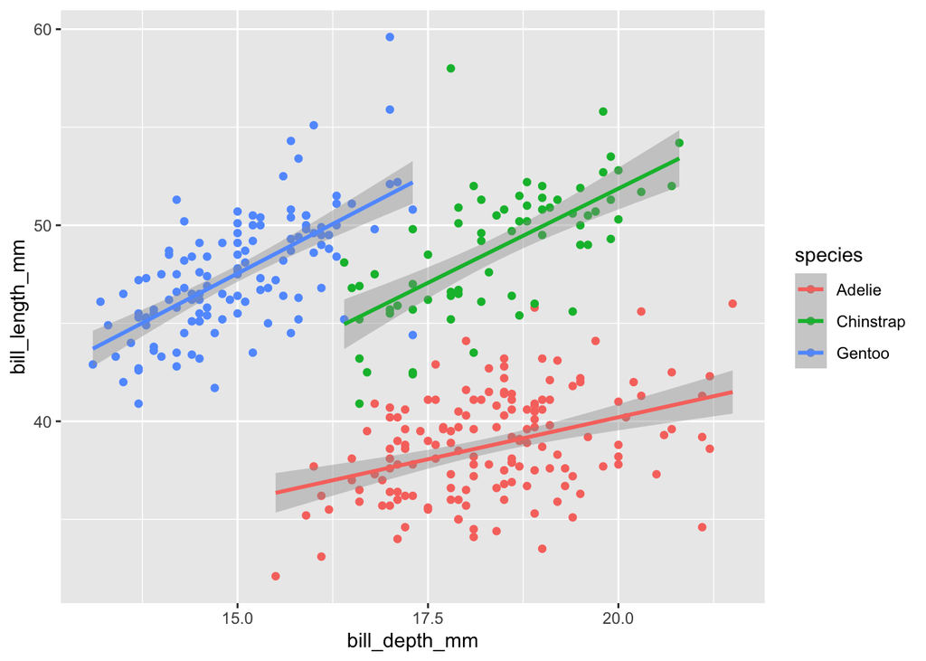

**Must have `bill_length_mm` as response (y) and `bill_depth_mm` as explanatory (x).**

#### 8. Do the three species of penguin have the same bill shape (i.e., the relationship between length and depth)? How do you know?

**Response:**

*Overall, the shape of the lines look similar. However, there are some slight differences in the slopes of the lines, which may suggest there are small differences in the bill shapes between these species.*

## Simulation

#### 1. Explain in one sentence why `pnorm(-4, mean = 2, sd = 4)` equals 0.0668072.

**Response:**

*The cumulative probability of observing a value less than or equal to -4 for the specified Normal distribution is 0.067.*

#### 2. Explain in one sentence why `qnorm(.975, mean = 2, sd = 4)` equals 9.8398559.

**Response:**

*The 97.5th quantile of the specified Normal distribution is 9.84.*

#### 3. Explain in one sentence why `dnorm(1.5, mean = 2, sd = 4)` equals 0.0989594.

**Response:**

#### 4. Explain in one sentence why `rnorm(mean = 0, sd = 1)` gives an error.

**Response:**

*There is no argument supplied for `n` the number of observations to generate.*

#### 5. Explain in one sentence why `dnorm(2, mean = 0, sd = 1)` will always produce a number between 0 and 1.

**Response:**

*Because `dnorm()` calculates the probability density of the Normal distribution and a probability of an observation is always between 0 and 1.*

#### 6. Re-create this plot from the lecture slides:

**Response:** Should have something resembling the following plot,

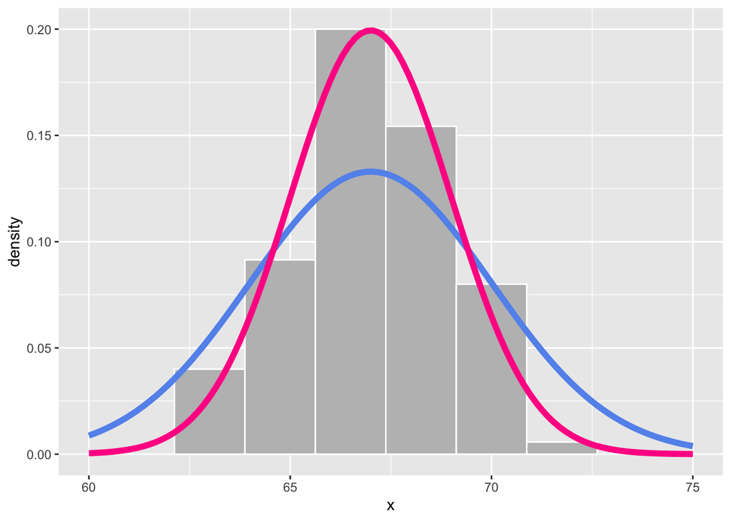